# Stability Data Study

Sarah Fondots

March 20, 2019

### Introduction

**Data Set**: #1  
**Compound**: 3119372  
**Name of Drug**: Foo Bar  
**Treats**: Helps a patient come up with a name for a function or object  
**Design of study**: Long-term NDA  
**Zone/Conditions**: USA

### Explanation of a stability study

As described in the [Koleva paper](https://github.com/ActaeaPachypoda/STA319/blob/master/Data/stability-Koleva.pdf) drug stability is the capacity to remain within the established specifications, i.e to maintain its identity, strength, quality and purity throughout the retest or expiration dating periods. Therefore a stability tests are a series of tests designed to obtain information on the stability of a pharmaceutical product in order to define its shelf life and utilization period under specified package and storage conditions.

### Analysis

#### Description of statistical methods

An NDA study estimates a drug expirations dating period applicable to all future batches. As a long term study we tested our drug over the course of 12 months with samples taken and tested at 0,3,6,9 and 12 months. As our intended market for this drug is the United States we followed all USDA guidlines and maintained testing conditions of $25^\circ c\pm 2^\circ$ and $60\%$ RH $\pm 5 \%$.

#### Plots

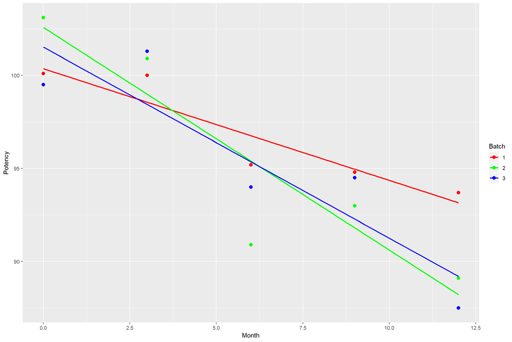

```
##
## Call:
## lm(formula = Potency ~ Month + stabilityData$batch + Month *
##     stabilityData$batch)
##
## Residuals:
##     Min      1Q  Median      3Q     Max
## -4.9400 -1.1167 -0.0167  1.5700  2.8233
##
## Coefficients:
##                           Estimate Std. Error t value Pr(>|t|)
## (Intercept)               100.3267     2.8417  35.305 1.13e-12 ***
## Month                      -0.5144     0.3867  -1.330    0.210
## stabilityData$batch         0.5800     1.3154   0.441    0.668
## Month:stabilityData$batch  -0.2133     0.1790  -1.192    0.258
## ---
## Signif. codes:  0 '***' 0.001 '**' 0.01 '*' 0.05 '.' 0.1 ' ' 1
##
## Residual standard error: 2.402 on 11 degrees of freedom
## Multiple R-squared:  0.799,  Adjusted R-squared:  0.7442
## F-statistic: 14.58 on 3 and 11 DF,  p-value: 0.000378
```

```
##
## Call:
## lm(formula = Potency ~ Month, data = stabilityData)
##
## Residuals:
##     Min      1Q  Median      3Q     Max
## -4.9400 -1.6133 -0.0167  1.6983  3.5067
##
## Coefficients:
##             Estimate Std. Error t value Pr(>|t|)
## (Intercept) 101.4867     1.0851  93.524  < 2e-16 ***
## Month        -0.9411     0.1477  -6.373 2.44e-05 ***
## ---
## Signif. codes:  0 '***' 0.001 '**' 0.01 '*' 0.05 '.' 0.1 ' ' 1
##
## Residual standard error: 2.426 on 13 degrees of freedom
## Multiple R-squared:  0.7575, Adjusted R-squared:  0.7389
## F-statistic: 40.62 on 1 and 13 DF,  p-value: 2.445e-05
```